# Search

```r
#Examine levels for categorical data
look$Categorical %>% select(label, n, levels_n)
```

```
##                                 label   n levels_n
## study_id                     study_id 359      359
## PSI_total_clinical PSI_total_clinical 359        2
## TC_gender                   TC_gender 358        2
## PC_gender                   PC_gender 358        2
## PC_reltoTC                 PC_reltoTC 358        9
## PC_marital_status   PC_marital_status 358        6
## PC_partner_inhome   PC_partner_inhome 358        2
## PC_yrs_ed                   PC_yrs_ed 358       16
## AC_yrs_ed                   AC_yrs_ed 301       15
## PC_employment           PC_employment 358       10
## AC_employment           AC_employment 300        9
## PC_annual_income     PC_annual_income 357       13
## PC_fam_learning       PC_fam_learning 358        2
## PC_fam_mentalh         PC_fam_mentalh 358        2
## TC_diagnosis             TC_diagnosis 356       15
## TC_diagnosis_age     TC_diagnosis_age 346        6
## TC_SPED                       TC_SPED 350        4
## TC_other_services   TC_other_services 357        2
```

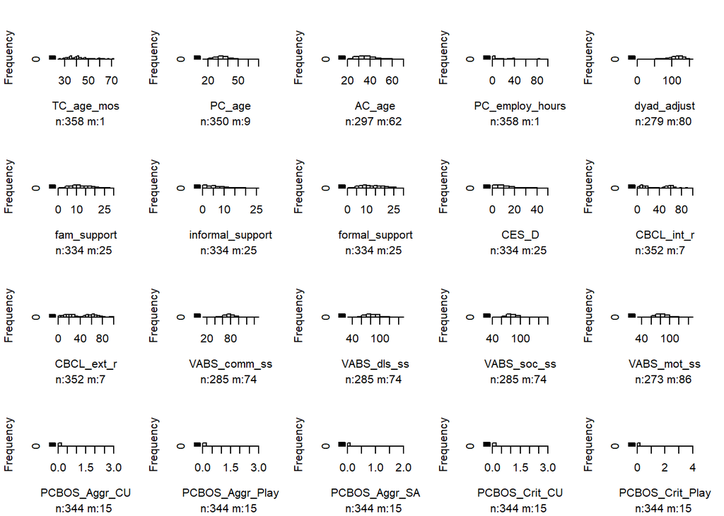

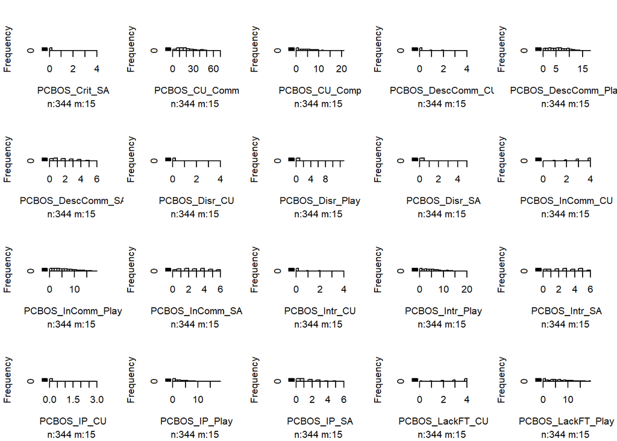

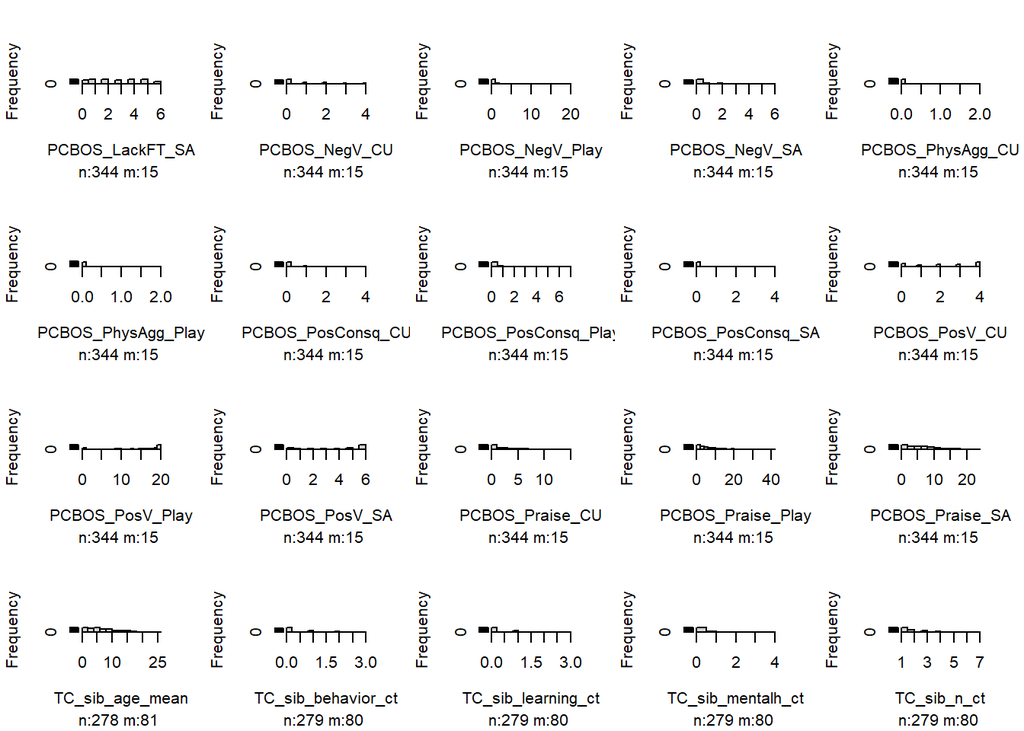

```r
#look @ distributions of numeric data
cont_labels <- look$Continuous$label
hist.data.frame(og_data %>% select(all_of(cont_labels)))
```

Preprocessing Steps - 1) Get rid of rows with no outcome data (moved out of blueprint for error testing) 2) Missing variable column for - AC Age, TC_sib (NA is meaningful) 3) Make yrs ed into numeric variable Make income into numeric variable Make age @ dx into numeric variable 4) For factor variables w/ high number of levels, make “other” 5) Dummy code categorical variables, and drop OG 6) Multiple imputation is reasonable for most variables 7) For variables where NA is meaningful (= absence of AC or sib, set remaining values to 0 for regression models)

## Making a Blueprint

```r
outcome <- "PSI_total_clinical"
cat2num <- names(select(og_data, matches("yrs_ed|diagnosis_age|income"))) #variables that will be recoded to be numeric
categorical <- names(select(og_data, where(is.character) & !(matches("id|PSI"))))
categorical <- categorical[!categorical %in% cat2num]
numeric <- c(names(select(og_data, where(is.numeric))), cat2num)
already_dum <- names(select(og_data, matches("TC_race|gov_assist|TC_sib_yes_ct"))) #some variables already "dummy" coded
true_numeric <- numeric[!numeric %in% already_dum]
na_true <- names(select(og_data, matches("AC|TC_sib", ignore.case = FALSE))) #don't impute data for alternate caregiver or subling variables
impute_vars <- true_numeric[!true_numeric %in% na_true]

stress_blueprint <- recipe(x = og_data,
                    vars = names(og_data),
                    roles = c("ID", "outcome", rep("predictor", 86))) %>%
                    #step_filter(!is.na(PSI_total_clinical), skip = FALSE) %>% #causing error
                    step_indicate_na(matches("AC_age", "TC_sib_yes_ct")) %>%
                    step_other(matches("PC_reltoTC|employment|TC_diagnosis|PC_marital_status|TC_SPED")) %>%
  #making yrs ed numeric
                    step_mutate(across(matches("yrs_ed"), ~case_when(
                    str_detect(., "No formal") ~ 0,
                    str_detect(., "7th grade") ~ 7,
                    str_detect(., "Junior high") ~ 8,
                    str_detect(., "Partial high school") ~ 9,
                    str_detect(., "GED") ~ 12,
                    str_detect(., "Partial college") ~ 13,
                    str_detect(., "Specialized") ~ 14,
                    str_detect(., "Associates") ~ 14,
                    str_detect(., "university grad") ~ 16,
                    str_detect(., "Grad prof") ~ 18))) %>%
  #making dx age numeric
                    step_mutate(across(matches("diagnosis_age"), ~case_when(
                    str_detect(., "At birth") ~ 6,
                    str_detect(., "One") ~ 18,
                    str_detect(., "Two") ~ 30,
                    str_detect(., "Three") ~ 42,
                    str_detect(., "Four") ~ 54,
                    str_detect(., "Five") ~ 66))) %>%
  #making annual income numeric
                    step_mutate(PC_annual_income =
                                  ifelse(str_detect(PC_annual_income, "less"), 2500,
                                  ifelse(str_detect(PC_annual_income, "14,999"), 12500,
                                  ifelse(str_detect(PC_annual_income, "19,999"), 17500,
                                  ifelse(str_detect(PC_annual_income, "24,999"), 22500,
                                  ifelse(str_detect(PC_annual_income, "29,999"), 27500,
                                  ifelse(str_detect(PC_annual_income, "39,999"), 35000,
                                  ifelse(str_detect(PC_annual_income, "49,999"), 45000,
                                  ifelse(str_detect(PC_annual_income, "59,999"), 55000,
                                  ifelse(str_detect(PC_annual_income, "69,999"), 65000,
                                  ifelse(str_detect(PC_annual_income, "79,999"), 75000,
                                  ifelse(str_detect(PC_annual_income, "89,999"), 85000,
                                  ifelse(str_detect(PC_annual_income, "more"), 95000,
                                  ifelse(is.na(PC_annual_income), NA, 7500)))))))))))))) %>% #5,000 and $9,999 in all others
                    step_impute_mode(all_of(categorical)) %>%
                    step_zv(all_of(numeric)) %>%
                    step_dummy(all_of(categorical)) %>%
                    step_mutate(across(matches("AC|TC_sib", ignore.case = FALSE),
                                       ~replace_na(., 0))) %>%
                    step_impute_knn(all_of(impute_vars), all_of(already_dum)) %>%
                    step_normalize(all_of(true_numeric))
```

```r
prepare <- prep(stress_blueprint, training = og_data)
stress_data <- bake(prepare, new_data = og_data)

head(stress_data)
```

```
## # A tibble: 6 x 101
##   study_id PSI_total_clinical TC_age_mos PC_age AC_age TC_race_Wh TC_race_Bl
##   <fct>    <fct>                   <dbl>  <dbl>  <dbl>      <int>      <int>
## 1 OP101    Yes                    -0.131  0.303  0.548          1          0
## 2 OP102    Yes                    -1.08  -0.968 -1.91           1          0
## 3 OP103    Yes                    -0.131 -0.587 -0.127          1          0
## 4 OP104    No                     -1.27   0.430  0.241          1          0
## 5 OP105    Yes                    -0.226 -0.332  0.364          1          0
## 6 OP106    Yes                    -0.226  0.303  0.425          0          0
## # ... with 94 more variables: TC_race_His <int>, TC_race_As <int>,
## #   TC_race_Nat <int>, TC_race_Pac <int>, TC_race_Oth <int>, PC_yrs_ed <dbl>,
## #   AC_yrs_ed <dbl>, PC_employ_hours <dbl>, PC_annual_income <dbl>,
## #   gov_assist <int>, TC_diagnosis_age <dbl>, dyad_adjust <dbl>,
## #   fam_support <dbl>, informal_support <dbl>, formal_support <dbl>,
## #   CES_D <dbl>, CBCL_int_r <dbl>, CBCL_ext_r <dbl>, VABS_comm_ss <dbl>,
## #   VABS_dls_ss <dbl>, VABS_soc_ss <dbl>, VABS_mot_ss <dbl>, ...
```

```r
#Check for missingness
look2 <- ff_glimpse(stress_data)

look2$Continuous %>% arrange(desc(missing_n)) %>% filter(missing_n > 0)
```

```
##  [1] label           var_type        n               missing_n
##  [5] missing_percent mean            sd              min
##  [9] quartile_25     median          quartile_75     max
## <0 rows> (or 0-length row.names)
```

```r
look2$Categorical %>% arrange(missing_n) %>% filter(missing_n > 0)
```

```
## [1] label           var_type        n               missing_n
## [5] missing_percent levels_n        levels          levels_count
## [9] levels_percent
## <0 rows> (or 0-length row.names)
```

## Test and Training Set

```r
  set.seed(121221)
  split <- initial_split(og_data, prop = .75)
  stress_train <- training(split)
  stress_test <- testing(split)

prepare <- prep(stress_blueprint,
                training = stress_train)

baked_train <- bake(prepare, new_data = stress_train)
baked_test <- bake(prepare, new_data = stress_test)
```

## Functions

```r
##Making a crossfold function

crossfold_log <- function(training_data, folds){

  #shuffle data
  traning_data <- training_data[sample(nrow(training_data)),]


    # Create 10 folds with equal size

      N_folds = cut(seq(1,nrow(training_data)),breaks= folds,labels=FALSE)

    # Create the list for each fold

      my.indices <- vector('list',folds)
      for(i in 1:folds){
        my.indices[[i]] <- which(N_folds!=i)
      }

      #cross validation settings

      cv <- trainControl(method    = "cv",
                   index           = my.indices,
                   classProbs      = TRUE,
                   summaryFunction = mnLogLoss)


return(cv)
}

#Making an accuracy function

accuracy <- function(observed_vector, predicted_vector){
tab <- table(predicted_vector,
             observed_vector,
             dnn = c('Predicted','Observed'))



tn <- tab[1,1]
tp <- tab[2,2]
fp <- tab[2,1]
fn <- tab[1,2]

acc <- (tp + tn)/(tp+tn+fp+fn)

return(acc)
}
```